# Tema 05 - Repaso

Variabilidad muestral y regresión lineal

Autores/as

Afiliación

Pedro Albarrán

Dpto. de Fundamentos del Análisis Económico. Universidad de Alicante

Henry Redondo

Esta lectura repasa lo que ya visteis en cursos anteriores y hay que traer estudiado a la primera clase del Tema 05. Los ejemplos son del caso del tema: una cadena de tiendas que encuestó a 404 de sus clientes.

# 1 Una muestra entre muchas

## 1.1 Población, muestra y estimador

La **población** es el conjunto de individuos sobre el que queremos aprender algo. Algunas poblaciones son fijas y podrían observarse enteras, aunque con un coste enorme, como los habitantes de un país en una fecha. En general, la población se define de forma potencial: la de clientes de una cadena incluye a los pasados, los actuales y los futuros, y a los de tiendas que aún no han abierto en zonas nuevas. Es inabarcable, y lo que observamos es una **muestra**, con la que aprendemos sobre el resto.[^1] En los ejemplos, la muestra son $n = 404$ clientes encuestados.

Una característica numérica de la población se denomina **parámetro**. Por ejemplo, el gasto medio de los clientes en la población, que representamos por $\mu$, es un parámetro poblacional. Como desconocemos su valor, utilizamos la información de la muestra para aproximarlo mediante un **estimador**.

Para estimar el gasto medio, observamos cuánto ha gastado cada cliente encuestado. Si identificamos a los clientes mediante $i = 1, \dots, n$ y llamamos $Y_i$ al gasto del cliente $i$, nuestra muestra está formada por las observaciones $Y_1, Y_2, \dots, Y_n$.

El estimador más sencillo de la media poblacional $\mu$ es la **media muestral**, $\bar Y$, que se obtiene sumando los gastos de todos los clientes encuestados y dividiendo entre el número de observaciones:

$$\bar Y = \frac{1}{n}\sum_{i=1}^{n} Y_i = \frac{Y_1 + Y_2 + \cdots + Y_n}{n}.$$

Así, $\mu$ es el gasto medio en la población y $\bar Y$ el de los 404 encuestados. Usamos el segundo para aproximar el primero.

## 1.2 La distribución muestral

Si seleccionáramos otra muestra aleatoria de clientes, obtendríamos un valor diferente de $\bar Y$. Por tanto, la media muestral es una **variable aleatoria**: su valor depende de la muestra seleccionada. Esto significa que tiene una distribución de probabilidad, denominada **distribución muestral**, que describe cómo varía el estimador entre distintas muestras.

Supongamos que las observaciones son independientes y proceden de una misma población, con media $\mu$ y desviación típica $\sigma$. Bajo estas condiciones, podemos calcular la esperanza y la varianza de la media muestral:

$$E[\bar Y] = \mu, \qquad
Var(\bar Y) = Var\Bigl(\frac{1}{n}\sum_{i=1}^{n}Y_i\Bigr) = \frac{1}{n^2}\,n\sigma^2 = \frac{\sigma^2}{n}.$$

La primera expresión indica que la media muestral es un estimador **insesgado**: si repitiéramos el muestreo muchas veces, el promedio de las medias muestrales coincidiría con la verdadera media poblacional $\mu$.

La segunda expresión mide la **precisión del estimador**. Cuanto mayor es el tamaño de la muestra, menor es su varianza y, por tanto, menor es la variabilidad de las estimaciones entre muestras. En consecuencia, las muestras más grandes permiten estimar la media poblacional con mayor precisión.

## 1.3 El error estándar

La desviación típica de la distribución muestral de un estimador se denomina **error estándar**. En el caso de la media muestral, viene dado por:

$$\frac{\sigma}{\sqrt{n}}.$$

El error estándar mide cuánto varía la media muestral entre distintas muestras y, por tanto, nos permite evaluar la **precisión de nuestra estimación**. De esta expresión se derivan tres resultados importantes:

- **Aumentar el tamaño de la muestra mejora la precisión, pero con rendimientos decrecientes.** Como el error estándar depende de $\sqrt{n}$, para reducirlo a la mitad necesitamos multiplicar por cuatro el tamaño de la muestra. Por ejemplo, si la desviación típica del gasto es $\sigma = 1.400$ euros, una muestra de 100 clientes produce un error estándar de 140 euros; con 400 clientes se reduce a 70 euros y con 1.600, a 35 euros.
- **Podemos calcular cuántas observaciones necesitamos para alcanzar una precisión determinada.** Si queremos obtener un error estándar de $e$, podemos despejar el tamaño de la muestra:
  $$n = \left(\frac{\sigma}{e}\right)^2.$$
  Por ejemplo, si $\sigma = 1.400$ euros y queremos un error estándar de 20 euros, necesitamos encuestar a $n = (1.400/20)^2 = 4.900$ clientes.
- **La precisión depende del tamaño de la muestra, $n$, y de la variabilidad en la población, $\sigma$.**

En la práctica, normalmente desconocemos la desviación típica poblacional $\sigma$. Por ello, la sustituimos por la desviación típica de la muestra, $s$, y calculamos el **error estándar estimado**:

$$\frac{s}{\sqrt{n}}.$$

## 1.4 Intervalos de confianza

El error estándar mide cuánto varía la media muestral de una muestra a otra. Como no obtendremos siempre el mismo valor, acompañamos la estimación de un **intervalo de confianza**: un rango de valores plausibles para el parámetro, construido con un procedimiento que contiene el verdadero valor en un porcentaje conocido de las muestras, el **nivel de confianza** (por ejemplo, el 95%).

Para construirlo hace falta conocer la distribución muestral de $\bar Y$, pero solo tenemos una muestra y no podemos observarla. Hay que suponer algo:

1. **Datos normales.** Si los datos siguen una distribución normal en la población, $\bar Y$ es normal de forma **exacta**, para cualquier tamaño de muestra: $\bar Y \sim N\!\left(\mu,\ \sigma^2/n\right)$.
2. **Muestra grande.** Si no sabemos cómo se distribuyen los datos pero $n$ es grande, el **teorema central del límite** (TCL) dice que $\bar Y$ es aproximadamente normal, *sea cual sea* esa distribución: $\bar Y \overset{a}{\sim} N\!\left(\mu,\ \sigma^2/n\right)$.

En los dos casos, como en una normal el 95% de la probabilidad está a menos de 1,96 desviaciones típicas de la media, el intervalo al 95% es

$$\bar Y \pm 1{,}96 \cdot \text{error estándar}.$$

Con $\bar Y = 3.700$ y error estándar 70: de 3.562,8 a 3.837,2 euros. El 95% se refiere al procedimiento: repetido en muchas muestras, el intervalo contiene la media poblacional el 95% de las veces.

En clase veremos una tercera forma, el **bootstrap**, que aproxima la distribución muestral con técnicas computacionales y menos supuestos.

# 2 De la media a la media condicional

La media $E[Y]$ es el valor esperado de $Y$ para un individuo elegido al azar. Si tenemos información previa sobre él, como su sexo o su renta, podemos mejorar ese valor esperado usando la media de los que se le parecen. En los datos del tema, el gasto medio es de 3.699 euros, el de las mujeres de 4.489 y el de los hombres de 2.892: saber que un cliente es mujer cambia lo que esperamos que gaste, y por eso interesa distinguir por grupos. La **media condicional** $E[Y \mid X = x]$ es la media de $Y$ entre las observaciones con $X = x$. Si $X$ es el sexo, $x$ es cada uno de sus valores: sexo = mujer, sexo = hombre. Si $X$ es la renta, $x$ es cada nivel de renta: renta = 1.000, renta = 2.000, renta = 2.005, etc. Es una *función* de $X$, $f(x) = E[Y \mid X = x]$: a cada valor de $X$ le asigna la media de $Y$ de quienes tienen ese valor. Toda la modelización del tema consiste en estimar esa función. Escribimos

$$Y = f(X) + u, \qquad f(X) = E[Y \mid X], \qquad E[u \mid X] = 0 .$$

$f(X)$ es la parte de $Y$ que las $X$ explican y $u$ es todo lo demás (gustos, circunstancias, lo que no se mide). Que $u$ tenga media cero dado $X$ se sigue de la definición de $f$ como media condicional.

# 3 El modelo de regresión lineal

## 3.1 El modelo

El modelo lineal supone que la media condicional es una suma ponderada de los regresores:

$$Y = \beta_0 + \beta_1 X_1 + \beta_2 X_2 + \dots + \beta_k X_k + u ,
\qquad E[u \mid X_1,\dots,X_k] = 0 .$$

Notación que usaremos:

- $n$: número de observaciones; $i = 1,\dots,n$.
- $k$: número de regresores sin contar la constante; hay $k+1$ parámetros.
- $x_{ij}$: valor de la variable $j$ para la observación $i$.
- $\widehat\beta_j$: coeficiente *estimado* con la muestra; $\beta_j$, el valor poblacional desconocido.

## 3.2 Cómo se lee un coeficiente

- **Constante** $\beta_0$: la media de $Y$ cuando todas las $X$ valen cero (el grupo de referencia). A veces no tiene interpretación útil (renta cero, edad cero).
- **Regresor discreto**: $\beta_j$ es el cambio en la media de $Y$ cuando $X_j$ aumenta *una unidad*, *manteniendo constantes las demás variables del modelo* (*ceteris paribus*):
  $$\beta_j = E[Y \mid X_j = x + 1, \ldots] - E[Y \mid X_j = x, \ldots].$$
  El **regresor 0/1** (por ejemplo, descuento) es el caso particular con $x = 0$: $\beta_j$ es la diferencia de medias de $Y$ entre quienes tienen $X_j = 1$ y quienes tienen $X_j = 0$.
- **Regresor continuo**: $\beta_j$ es la derivada parcial,
  $$\beta_j = \frac{\partial E[Y\mid X]}{\partial X_j},$$
  y el cambio discreto por una unidad más, $E[Y \mid X_j = x + 1, \ldots] - E[Y \mid X_j = x, \ldots]$, es su aproximación.

Las **unidades** mandan: $\beta_j$ está en unidades de $Y$ por unidad de $X_j$. Si la renta pasa de euros a miles de euros, su coeficiente se multiplica por mil, y el modelo es el mismo. El tamaño de un coeficiente no dice, por sí solo, si la variable es importante.

## 3.3 Variables cualitativas

Una variable con $C$ categorías (zona: pueblo, ciudad, capital) entra en el modelo como $C-1$ variables 0/1 (*dummies*). La categoría sin dummy es la **referencia**, y cada coeficiente es la diferencia de media respecto a ella:

$$Y = \beta_0 + \beta_1\,\text{ciudad} + \beta_2\,\text{capital} + u
\quad\Longrightarrow\quad
\begin{cases}
E[Y\mid\text{pueblo}] = \beta_0\\
E[Y\mid\text{ciudad}] = \beta_0 + \beta_1\\
E[Y\mid\text{capital}] = \beta_0 + \beta_2
\end{cases}$$

Sin otras variables, la regresión reproduce exactamente las medias de cada grupo. No se pueden incluir las $C$ dummies junto con la constante: sumarían siempre 1 (la constante) y el modelo no tendría solución única. Es la *trampa de las dummies*. Cambiar la categoría de referencia deja el modelo igual y cambia solo cómo se leen los coeficientes.

# 4 Mínimos cuadrados ordinarios (MCO)

## 4.1 El problema

Para unos coeficientes candidatos $b_0,\dots,b_k$, la predicción de la observación $i$ es $\widehat y_i = b_0 + b_1 x_{i1} + \dots + b_k x_{ik}$ y el **residuo** es $\widehat e_i = y_i - \widehat y_i$. MCO elige los coeficientes que minimizan la **suma de cuadrados de los residuos**:

$$\boxed{\;\widehat{\beta} = \arg\min_{b_0,\dots,b_k}\
SCR = \sum_{i=1}^{n} \bigl(y_i - b_0 - b_1 x_{i1} - \dots - b_k x_{ik}\bigr)^2\;}$$

Se eleva al cuadrado para que los residuos positivos y negativos no se cancelen, y porque así el problema es una función cuadrática con un mínimo fácil de encontrar: igualando las derivadas a cero.

En el gráfico, 20 clientes de los datos del tema y dos rectas; los segmentos rojos son los residuos. La recta de MCO deja residuos mucho menores que la otra, y su suma de cuadrados es menos de la mitad.

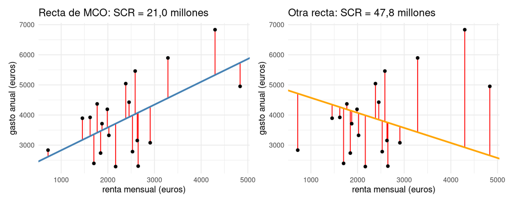

## 4.2 Un solo regresor

Con $y_i = \beta_0 + \beta_1 x_i + u_i$, las condiciones de primer orden son

$$\frac{\partial SCR}{\partial b_0} = -2\sum_i (y_i - b_0 - b_1 x_i) = 0, \qquad
\frac{\partial SCR}{\partial b_1} = -2\sum_i x_i (y_i - b_0 - b_1 x_i) = 0,$$

y su solución es

$$\widehat{\beta}_1 = \frac{\sum_i (x_i - \bar{x})(y_i - \bar{y})}{\sum_i (x_i - \bar{x})^2}
= \frac{\widehat{Cov}(x,y)}{\widehat{Var}(x)}, \qquad
\widehat{\beta}_0 = \bar{y} - \widehat{\beta}_1 \bar{x}.$$

Las condiciones de primer orden dicen que los residuos de MCO **suman cero** y **no se correlacionan con cada regresor**. Es la versión muestral de lo que el modelo supone en la población, $E[u\mid X] = 0$.

El **$R^2$** resume el ajuste: la fracción de la varianza de $Y$ que reproducen las predicciones, entre 0 y 1. El resto queda en los residuos.

# 5 Cuando el efecto no es constante: formas funcionales

Esta sección se verá en clase: leedla como adelanto.

El modelo lineal supone que el efecto de cada $X_j$ es siempre el mismo número, $\beta_j$. En economía casi nunca es así: hay rendimientos decrecientes, umbrales y efectos distintos por grupos. El modelo sigue siendo “lineal” (lineal *en los parámetros*) si transformamos las variables. Lo que cambia es cómo se leen los coeficientes.

## 5.1 Logaritmos

Un cambio en el logaritmo es, aproximadamente, un cambio proporcional: $\Delta \log x \approx \Delta x / x$, el cambio de $x$ en tanto por uno. Que $\log x$ aumente en 1 es que $x$ aumente un 100%, y que aumente en 0,01, que $x$ aumente un 1%; por eso el efecto de un 1% es el coeficiente dividido por 100. De ahí salen las tres lecturas:

| Modelo | Lectura de $\beta_1$ | Ejemplo con $\beta_1$ |
| --- | --- | --- |
| $y = \beta_0 + \beta_1 \log x$ | $x$ sube un 1% $\Rightarrow$ $y$ sube $\beta_1/100$ unidades | $\beta_1 = 1.500$: 15 euros |
| $\log y = \beta_0 + \beta_1 \log x$ | $x$ sube un 1% $\Rightarrow$ $y$ sube un $\beta_1$% (**elasticidad**) | $\beta_1 = 0{,}4$: un 0,4% |
| $\log y = \beta_0 + \beta_1 x$ | $x$ sube una unidad $\Rightarrow$ $y$ sube un $100\beta_1$% | $\beta_1 = 0{,}05$: un 5% |

La última lectura es una aproximación válida para coeficientes pequeños. El cambio exacto es $100\,(e^{\beta_1} - 1)\%$: con $\beta_1 = 0{,}05$ es 5,13% (casi igual), pero con $\beta_1 = 0{,}3$ es 34,99%, no 30%.

Con $y = \beta_0 + \beta_1 \log x$, un euro más de renta importa menos cuanto más renta se tiene: **rendimientos decrecientes**. Lo constante es el efecto de un 1% más. El logaritmo solo existe para valores positivos: las observaciones con $x = 0$ se pierden.

## 5.2 Polinomios

Una relación que sube y luego baja (el gasto con la edad) se recoge con una parábola:

$$y = \beta_0 + \beta_1 x + \beta_2 x^2 + u
\qquad\Longrightarrow\qquad
\frac{\partial E[y\mid x]}{\partial x} = \beta_1 + 2\beta_2 x .$$

Ahora el efecto de una unidad más de $x$ **depende de $x$**, y ni $\beta_1$ ni $\beta_2$ por separado son “el efecto”. Si $\beta_2 < 0$ la parábola es una U invertida, con máximo en $x^* = -\beta_1/(2\beta_2)$; si $\beta_2 > 0$, una U con mínimo ahí.

**Ejemplo (parábola).** $E[y\mid x] = 100 + 20x - 0{,}5x^2$. Efecto marginal: $20 - x$. Con $x = 10$, $+10$ por unidad; con $x = 20$, cero (es el máximo: $20/(2\cdot 0{,}5) = 20$); con $x = 30$, $-10$.

Con grados más altos (`poly(x, g)` con $g$ = 3, 4, …) la curva puede tomar formas más complicadas. Más grado significa más flexibilidad; en clase veremos su precio.

## 5.3 Tramos (funciones escalón)

Otra forma de seguir una curva sin imponer su forma: partir $x$ en **tramos** y meter una dummy por tramo (menos el de referencia). Cada coeficiente es la diferencia de media respecto al tramo de referencia, y *dentro* de un tramo $x$ no cambia nada: la función estimada es una escalera. Es más flexible que la parábola, pero depende de dónde se pongan los cortes. Los árboles de regresión (Tema 8) eligen esos cortes automáticamente.

## 5.4 Interacciones

Para que el efecto de una variable dependa de otra se incluye su producto:

$$y = \beta_0 + \beta_1\,\text{renta} + \beta_2\,\text{mujer} + \beta_3\,(\text{renta}\times\text{mujer}) + u .$$

- Para los hombres (mujer $=0$): $y = \beta_0 + \beta_1\,\text{renta}$; pendiente $\beta_1$.
- Para las mujeres (mujer $=1$): $y = (\beta_0 + \beta_2) + (\beta_1 + \beta_3)\,\text{renta}$; pendiente $\beta_1 + \beta_3$.

$\beta_3$ es la **diferencia de pendientes** y $\beta_2$ la diferencia de ordenadas en el origen. En general, $\partial E[y]/\partial\,\text{renta} = \beta_1 + \beta_3\,\text{mujer}$. Con una interacción, el coeficiente “principal” $\beta_2$ ya no es la diferencia media entre mujeres y hombres, sino la diferencia *cuando la renta vale cero*.

## Notas

[^1]: El tamaño no las distingue: una base de datos con millones de filas es una muestra si recoge clientes de unos años y unas zonas, y no de todos los que hay o podría haber.